# Figure 5: ER contacts and proximal ribosomes

# Fig 5C (top)

Fraction of reconstructed ER surface assigned to mitochondria-ER contacts (MERCS).

**Source data**  
`Fig 5C.csv`

**Columns**

- `Date` — Experiment date
- `Condition` — Control or TTX
- `Mito` — Mitochondrial reconstruction ID
- `ER_surf_um2` — Endoplasmic reticulum surface area (µm²)
- `ERMCS_surf_um2` — Mitochondria–ER contact area (µm²)

## Data

The contact fraction is ERMCS surface area divided by total ER surface area.

```r
condition_order <- c("Control", "TTX")
spacing_map <- c("Control" = 1, "TTX" = 2.2)

Density <- read_csv("./Fig 5C.csv", show_col_types = FALSE) %>%
  filter(Condition %in% condition_order) %>%
  mutate(
    Condition = factor(Condition, levels = condition_order),
    Date = factor(trimws(as.character(Date))),
    across(c(ERMCS_surf_um2, ER_surf_um2), as.numeric),
    MERCS_per_ER = ERMCS_surf_um2 / ER_surf_um2,
    x_pos = unname(spacing_map[as.character(Condition)]),
    color_key = paste(Condition, Date, sep = "_")
  ) %>%
  filter(is.finite(MERCS_per_ER), ER_surf_um2 > 0)

if (nrow(Density) == 0) stop("No valid MERCS/ER measurements remain.")

Density %>%
  mutate(across(where(is.numeric), ~ round(.x, 3)))
```

| Date | Condition | Mito | OMM_surf_um2 | ER_surf_um2 | ERMCS_surf_um2 | MERCS_per_ER | x_pos | color_key |
| --- | --- | --- | --- | --- | --- | --- | --- | --- |
| 2022-08-10 | Control | 1 | 0.524 | 1.170 | 0.153 | 0.131 | 1.0 | Control_2022-08-10 |
| 2022-08-10 | Control | 2 | 0.487 | 1.233 | 0.200 | 0.162 | 1.0 | Control_2022-08-10 |
| 2022-08-10 | Control | 3 | 0.557 | 0.417 | 0.100 | 0.240 | 1.0 | Control_2022-08-10 |
| 2022-08-10 | Control | 4 | 0.560 | 0.251 | 0.049 | 0.195 | 1.0 | Control_2022-08-10 |
| 2023-01-04 | Control | 5 | 0.508 | 0.399 | 0.085 | 0.213 | 1.0 | Control_2023-01-04 |
| 2023-01-04 | Control | 6 | 0.557 | 1.010 | 0.090 | 0.089 | 1.0 | Control_2023-01-04 |
| 2023-01-04 | Control | 7 | 0.535 | 0.899 | 0.075 | 0.083 | 1.0 | Control_2023-01-04 |
| 2023-01-04 | Control | 8 | 0.675 | 0.955 | 0.096 | 0.101 | 1.0 | Control_2023-01-04 |
| 2023-01-04 | Control | 9 | 0.676 | 0.769 | 0.085 | 0.111 | 1.0 | Control_2023-01-04 |
| 2023-01-04 | Control | 10 | 0.500 | 0.759 | 0.122 | 0.161 | 1.0 | Control_2023-01-04 |

[output cut: 32 more lines]

## Summary

```r
summary_table <- Density %>%
  group_by(Condition) %>%
  summarise(
    n_Mitochondria = n(),
    n_Experiment_Dates = n_distinct(Date),
    `Mean (SE)` = sprintf("%.3f (%.3f)", mean(MERCS_per_ER), sd(MERCS_per_ER) / sqrt(n())),
    .groups = "drop"
  )

summary_table
```

| Condition | n_Mitochondria | n_Experiment_Dates | Mean (SE) |
| --- | --- | --- | --- |
| Control | 21 | 3 | 0.139 (0.014) |
| TTX | 21 | 3 | 0.266 (0.021) |

## Statistics

Two-way ANOVA with condition, experiment date, and their interaction (Type I sums of squares).

```r
fit_aov <- aov(MERCS_per_ER ~ Condition * Date, data = Density)
anova_table <- anova(fit_aov)
condition_p <- as.numeric(anova_table["Condition", "Pr(>F)"])
format_p <- function(p) ifelse(p < 0.0001, "<0.0001", sprintf("%.4f", p))

group_means <- Density %>%
  group_by(Condition) %>%
  summarise(mean = mean(MERCS_per_ER), SE = sd(MERCS_per_ER) / sqrt(n()), .groups = "drop")

stats_table <- tibble(
  Test = "Two-way ANOVA",
  Comparison = "Control vs TTX",
  `Control mean (SE)` = sprintf("%.3f (%.3f)", group_means$mean[1], group_means$SE[1]),
  `TTX mean (SE)` = sprintf("%.3f (%.3f)", group_means$mean[2], group_means$SE[2]),
  `Condition p` = format_p(condition_p)
)

stats_table
```

| Test | Comparison | Control mean (SE) | TTX mean (SE) | Condition p |
| --- | --- | --- | --- | --- |
| Two-way ANOVA | Control vs TTX | 0.139 (0.014) | 0.266 (0.021) | <0.0001 |

## Plot

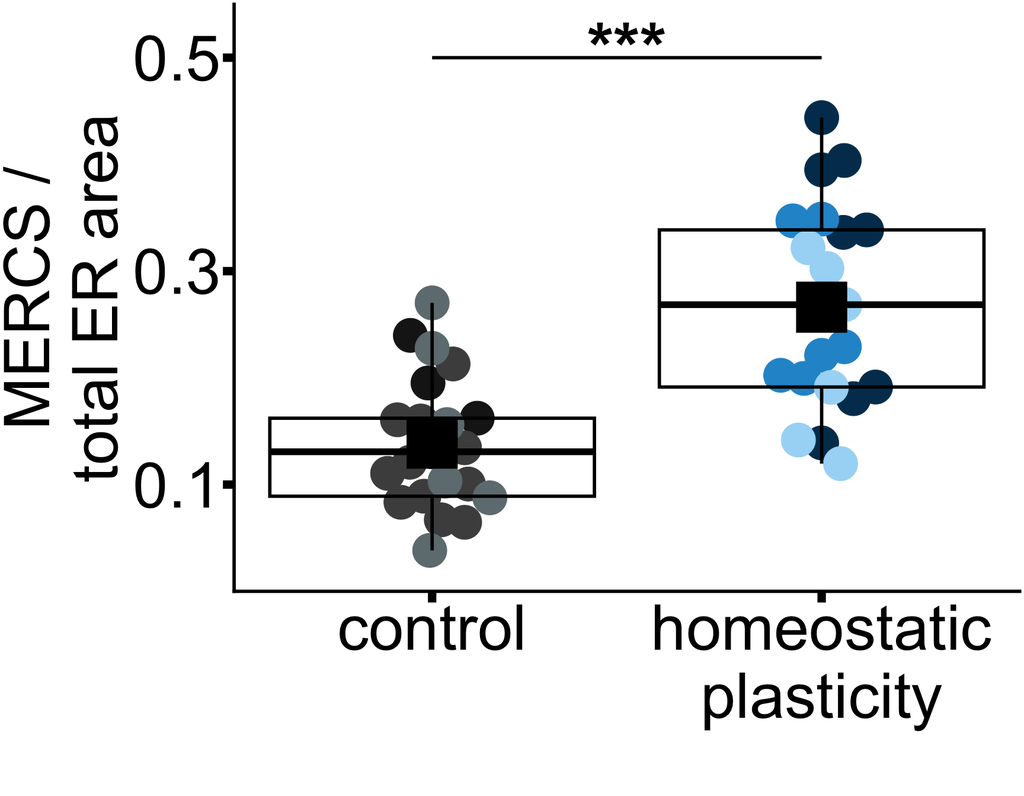

```r
set.seed(20261109)
p_to_stars <- function(p) case_when(
  p < 0.001 ~ "***", p < 0.01 ~ "**",
  p < 0.05 ~ "*", TRUE ~ "ns"
)

test_results <- tibble(
  group1_x = spacing_map["Control"],
  group2_x = spacing_map["TTX"],
  y_position = 0.5,
  stars = p_to_stars(condition_p)
) %>%
  filter(stars != "ns")

date_levels <- levels(Density$Date)

date_colors <- c(
  setNames(rep(c("#1A1A1A", "#4D4D4D", "#6F7C80"), length.out = length(date_levels)),
           paste("Control", date_levels, sep = "_")),
  setNames(rep(c("#003B5C", "#2596D1", "#A6D9F5"), length.out = length(date_levels)),
           paste("TTX", date_levels, sep = "_"))
)

fig5c_top_plot <- ggplot(Density, aes(x_pos, MERCS_per_ER, color = color_key)) +
  ggbeeswarm::geom_beeswarm(cex = 6, priority = "random", size = 20,
                            alpha = 1, corral = "random") +
  geom_boxplot(aes(group = x_pos), fill = NA, width = 1, outlier.shape = NA,
               linewidth = 2, color = "black") +
  stat_summary(aes(group = x_pos), fun = mean, geom = "point",
               shape = 15, size = 30, color = "black") +
  geom_segment(data = test_results,
               aes(x = group1_x, xend = group2_x, y = y_position, yend = y_position),
               inherit.aes = FALSE, linewidth = 2, color = "black") +
  geom_text(data = test_results,
            aes(x = (group1_x + group2_x) / 2, y = y_position + 0.01, label = stars),
            inherit.aes = FALSE, size = 30, color = "black", fontface = "bold") +
  scale_x_continuous(breaks = unname(spacing_map),
                     labels = c("control", "homeostatic\nplasticity")) +
  scale_color_manual(values = date_colors) +
  scale_y_continuous(oob = scales::oob_keep, breaks = c(0.1, 0.3, 0.5),
                     limits = c(0, 0.55), expand = c(0, 0)) +
  labs(x = "", y = "MERCS /\ntotal ER area") +
  theme_classic() +
  theme(
    axis.title = element_text(size = 80, color = "black"),
    axis.text = element_text(size = 80, color = "black"),
    axis.ticks = element_line(linewidth = 5, color = "black"),
    axis.ticks.length = grid::unit(0.5, "cm"),
    axis.line = element_line(linewidth = 2, color = "black"),
    legend.position = "none"
  )

fig5c_top_plot
```

# Fig 5C (bottom)

Total reconstructed ER surface area surrounding juxtaspinal mitochondrial regions.

**Source data**  
`Fig 5C.csv`

**Columns**

- `Date` — Experiment date
- `Condition` — Control or TTX
- `Mito` — Mitochondrial reconstruction ID
- `ER_surf_um2` — Endoplasmic reticulum surface area (µm²)

## Data

```r
condition_order <- c("Control", "TTX")
spacing_map <- c("Control" = 1, "TTX" = 2.2)

Density <- read_csv("./Fig 5C.csv", show_col_types = FALSE) %>%
  filter(Condition %in% condition_order) %>%
  mutate(
    Condition = factor(Condition, levels = condition_order),
    Date = factor(trimws(as.character(Date))),
    ER_surf_um2 = as.numeric(ER_surf_um2),
    x_pos = unname(spacing_map[as.character(Condition)]),
    color_key = paste(Condition, Date, sep = "_")
  ) %>%
  filter(is.finite(ER_surf_um2))

if (nrow(Density) == 0) stop("No valid ER surface-area measurements remain.")

Density %>%
  mutate(across(where(is.numeric), ~ round(.x, 3)))
```

| Date | Condition | Mito | OMM_surf_um2 | ER_surf_um2 | ERMCS_surf_um2 | x_pos | color_key |
| --- | --- | --- | --- | --- | --- | --- | --- |
| 2022-08-10 | Control | 1 | 0.524 | 1.170 | 0.153 | 1.0 | Control_2022-08-10 |
| 2022-08-10 | Control | 2 | 0.487 | 1.233 | 0.200 | 1.0 | Control_2022-08-10 |
| 2022-08-10 | Control | 3 | 0.557 | 0.417 | 0.100 | 1.0 | Control_2022-08-10 |
| 2022-08-10 | Control | 4 | 0.560 | 0.251 | 0.049 | 1.0 | Control_2022-08-10 |
| 2023-01-04 | Control | 5 | 0.508 | 0.399 | 0.085 | 1.0 | Control_2023-01-04 |
| 2023-01-04 | Control | 6 | 0.557 | 1.010 | 0.090 | 1.0 | Control_2023-01-04 |
| 2023-01-04 | Control | 7 | 0.535 | 0.899 | 0.075 | 1.0 | Control_2023-01-04 |
| 2023-01-04 | Control | 8 | 0.675 | 0.955 | 0.096 | 1.0 | Control_2023-01-04 |
| 2023-01-04 | Control | 9 | 0.676 | 0.769 | 0.085 | 1.0 | Control_2023-01-04 |
| 2023-01-04 | Control | 10 | 0.500 | 0.759 | 0.122 | 1.0 | Control_2023-01-04 |

[output cut: 32 more lines]

## Summary

```r
summary_table <- Density %>%
  group_by(Condition) %>%
  summarise(
    n_Mitochondria = n(),
    n_Experiment_Dates = n_distinct(Date),
    `Mean (SE)` = sprintf("%.3f (%.3f)", mean(ER_surf_um2), sd(ER_surf_um2) / sqrt(n())),
    .groups = "drop"
  )

summary_table
```

| Condition | n_Mitochondria | n_Experiment_Dates | Mean (SE) |
| --- | --- | --- | --- |
| Control | 21 | 3 | 0.802 (0.082) |
| TTX | 21 | 3 | 0.617 (0.051) |

## Statistics

Two-way ANOVA with condition, experiment date, and their interaction (Type I sums of squares).

```r
fit_aov <- aov(ER_surf_um2 ~ Condition * Date, data = Density)
anova_table <- anova(fit_aov)
condition_p <- as.numeric(anova_table["Condition", "Pr(>F)"])
format_p <- function(p) ifelse(p < 0.0001, "<0.0001", sprintf("%.4f", p))

group_means <- Density %>%
  group_by(Condition) %>%
  summarise(mean = mean(ER_surf_um2), SE = sd(ER_surf_um2) / sqrt(n()), .groups = "drop")

stats_table <- tibble(
  Test = "Two-way ANOVA",
  Comparison = "Control vs TTX",
  `Control mean (SE)` = sprintf("%.3f (%.3f)", group_means$mean[1], group_means$SE[1]),
  `TTX mean (SE)` = sprintf("%.3f (%.3f)", group_means$mean[2], group_means$SE[2]),
  `Condition p` = format_p(condition_p)
)

stats_table
```

| Test | Comparison | Control mean (SE) | TTX mean (SE) | Condition p |
| --- | --- | --- | --- | --- |
| Two-way ANOVA | Control vs TTX | 0.802 (0.082) | 0.617 (0.051) | 0.0607 |

## Plot

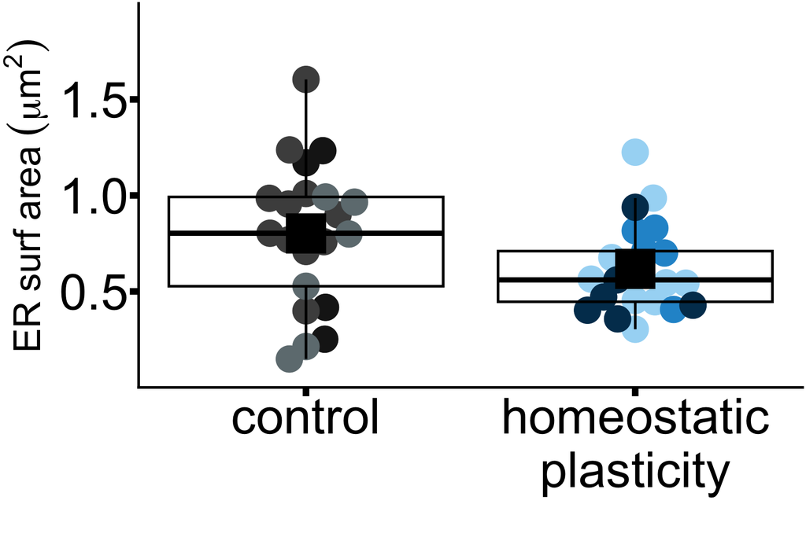

```r
set.seed(20261109)
p_to_stars <- function(p) case_when(
  p < 0.001 ~ "***", p < 0.01 ~ "**",
  p < 0.05 ~ "*", TRUE ~ "ns"
)

test_results <- tibble(
  group1_x = spacing_map["Control"],
  group2_x = spacing_map["TTX"],
  y_position = 1.8,
  stars = p_to_stars(condition_p)
) %>%
  filter(stars != "ns")

date_levels <- levels(Density$Date)

date_colors <- c(
  setNames(rep(c("#1A1A1A", "#4D4D4D", "#6F7C80"), length.out = length(date_levels)),
           paste("Control", date_levels, sep = "_")),
  setNames(rep(c("#A6D9F5", "#2596D1", "#003B5C"), length.out = length(date_levels)),
           paste("TTX", date_levels, sep = "_"))
)

fig5c_bottom_plot <- ggplot(Density, aes(x_pos, ER_surf_um2, color = color_key)) +
  ggbeeswarm::geom_beeswarm(cex = 6, priority = "random", size = 20,
                            alpha = 1, corral = "random") +
  geom_boxplot(aes(group = x_pos), fill = NA, width = 1, outlier.shape = NA,
               linewidth = 2, color = "black") +
  stat_summary(aes(group = x_pos), fun = mean, geom = "point",
               shape = 15, size = 30, color = "black") +
  geom_segment(data = test_results,
               aes(x = group1_x, xend = group2_x, y = y_position, yend = y_position),
               inherit.aes = FALSE, linewidth = 2, color = "black") +
  geom_text(data = test_results,
            aes(x = (group1_x + group2_x) / 2, y = y_position + 0.04, label = stars),
            inherit.aes = FALSE, size = 30, color = "black", fontface = "bold") +
  scale_x_continuous(breaks = unname(spacing_map),
                     labels = c("control", "homeostatic\nplasticity")) +
  scale_color_manual(values = date_colors) +
  scale_y_continuous(oob = scales::oob_keep, breaks = c(0.5, 1, 1.5), limits = c(0, 2), expand = c(0, 0)) +
  labs(x = "", y = expression(ER~surf~area~group("(", mu*m^2, ")"))) +
  theme_classic() +
  theme(
    axis.title = element_text(size = 60, color = "black"),
    axis.text = element_text(size = 80, color = "black"),
    axis.ticks = element_line(linewidth = 5, color = "black"),
    axis.ticks.length = grid::unit(0.5, "cm"),
    axis.line = element_line(linewidth = 2, color = "black"),
    legend.position = "none"
  )

fig5c_bottom_plot
```

# Fig 5D

Estimated number of ribosomes proximal to reconstructed juxtaspinal mitochondrial regions.

**Source data**  
`Fig 5D, E.csv`

**Columns**

- `Date` — Experiment date
- `Condition` — Control or TTX
- `Mito` — Mitochondrial reconstruction ID
- `n_ribosomes` — Estimated ribosome count within 50 nm of the outer mitochondrial membrane

## Data

```r
condition_order <- c("Control", "TTX")
spacing_map <- c("Control" = 1, "TTX" = 2.2)

Density <- read_csv("./Fig 5D, E.csv", show_col_types = FALSE) %>%
  filter(Condition %in% condition_order) %>%
  mutate(
    Condition = factor(Condition, levels = condition_order),
    Date = factor(trimws(as.character(Date))),
    n_ribosomes = as.numeric(n_ribosomes),
    x_pos = unname(spacing_map[as.character(Condition)]),
    color_key = paste(Condition, Date, sep = "_")
  ) %>%
  filter(is.finite(n_ribosomes))

if (nrow(Density) == 0) stop("No valid ribosome measurements remain.")

Density %>%
  mutate(across(where(is.numeric), ~ round(.x, 3)))
```

| Date | Condition | Mito | Ribo_vol_nm3 | Retained_Ribo_components | Smallest_Ribo_vol_nm3 | Average_Smallest_Ribo_vol_nm3 | n_ribosomes | x_pos | color_key |
| --- | --- | --- | --- | --- | --- | --- | --- | --- | --- |
| 2022-08-10 | Control | 1 | 127285.87 | 3 | 7472.989 | 4856.706 | 26 | 1.0 | Control_2022-08-10 |
| 2022-08-10 | Control | 2 | 0.00 | 0 | 0.000 | 4856.706 | 0 | 1.0 | Control_2022-08-10 |
| 2022-08-10 | Control | 3 | 30617.11 | 3 | 6071.504 | 4856.706 | 6 | 1.0 | Control_2022-08-10 |
| 2022-08-10 | Control | 4 | 201931.28 | 15 | 6250.771 | 4856.706 | 42 | 1.0 | Control_2022-08-10 |
| 2023-01-04 | Control | 5 | 0.00 | 0 | 0.000 | 4856.706 | 0 | 1.0 | Control_2023-01-04 |
| 2023-01-04 | Control | 6 | 0.00 | 0 | 0.000 | 4856.706 | 0 | 1.0 | Control_2023-01-04 |
| 2023-01-04 | Control | 7 | 0.00 | 0 | 0.000 | 4856.706 | 0 | 1.0 | Control_2023-01-04 |
| 2023-01-04 | Control | 8 | 0.00 | 0 | 0.000 | 4856.706 | 0 | 1.0 | Control_2023-01-04 |
| 2023-01-04 | Control | 9 | 0.00 | 0 | 0.000 | 4856.706 | 0 | 1.0 | Control_2023-01-04 |
| 2023-01-04 | Control | 10 | 0.00 | 0 | 0.000 | 4856.706 | 0 | 1.0 | Control_2023-01-04 |

[output cut: 32 more lines]

## Summary

```r
summary_table <- Density %>%
  group_by(Condition) %>%
  summarise(
    n_Mitochondria = n(),
    n_Experiment_Dates = n_distinct(Date),
    `Mean (SE)` = sprintf("%.3f (%.3f)", mean(n_ribosomes), sd(n_ribosomes) / sqrt(n())),
    .groups = "drop"
  )

summary_table
```

| Condition | n_Mitochondria | n_Experiment_Dates | Mean (SE) |
| --- | --- | --- | --- |
| Control | 21 | 3 | 4.667 (2.345) |
| TTX | 21 | 3 | 50.857 (12.890) |

## Statistics

Two-way ANOVA with condition, experiment date, and their interaction (Type I sums of squares).

```r
fit_aov <- aov(n_ribosomes ~ Condition * Date, data = Density)
anova_table <- anova(fit_aov)
condition_p <- as.numeric(anova_table["Condition", "Pr(>F)"])
format_p <- function(p) ifelse(p < 0.0001, "<0.0001", sprintf("%.4f", p))

group_means <- Density %>%
  group_by(Condition) %>%
  summarise(mean = mean(n_ribosomes), SE = sd(n_ribosomes) / sqrt(n()), .groups = "drop")

stats_table <- tibble(
  Test = "Two-way ANOVA",
  Comparison = "Control vs TTX",
  `Control mean (SE)` = sprintf("%.3f (%.3f)", group_means$mean[1], group_means$SE[1]),
  `TTX mean (SE)` = sprintf("%.3f (%.3f)", group_means$mean[2], group_means$SE[2]),
  `Condition p` = format_p(condition_p)
)

stats_table
```

| Test | Comparison | Control mean (SE) | TTX mean (SE) | Condition p |
| --- | --- | --- | --- | --- |
| Two-way ANOVA | Control vs TTX | 4.667 (2.345) | 50.857 (12.890) | 0.0010 |

## Plot

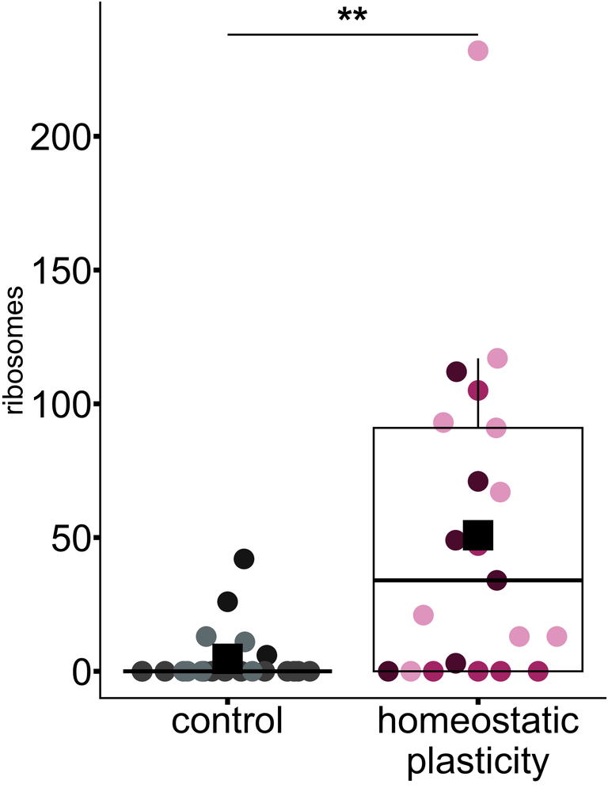

```r
set.seed(20261109)
p_to_stars <- function(p) case_when(
  p < 0.001 ~ "***", p < 0.01 ~ "**",
  p < 0.05 ~ "*", TRUE ~ "ns"
)

test_results <- tibble(
  group1_x = spacing_map["Control"],
  group2_x = spacing_map["TTX"],
  y_position = 238,
  stars = p_to_stars(condition_p)
) %>%
  filter(stars != "ns")

date_levels <- levels(Density$Date)

date_colors <- c(
  setNames(rep(c("#1A1A1A", "#4D4D4D", "#6F7C80"), length.out = length(date_levels)),
           paste("Control", date_levels, sep = "_")),
  setNames(rep(c("#E6A8C8", "#B33A78", "#5C123A"), length.out = length(date_levels)),
           paste("TTX", date_levels, sep = "_"))
)

fig5d_plot <- ggplot(Density, aes(x_pos, n_ribosomes, color = color_key)) +
  ggbeeswarm::geom_beeswarm(cex = 9, priority = "random", size = 20,
                            alpha = 1, corral = "random") +
  geom_boxplot(aes(group = x_pos), fill = NA, width = 1, outlier.shape = NA,
               linewidth = 2, color = "black") +
  stat_summary(aes(group = x_pos), fun = mean, geom = "point",
               shape = 15, size = 30, color = "black") +
  geom_segment(data = test_results,
               aes(x = group1_x, xend = group2_x, y = y_position, yend = y_position),
               inherit.aes = FALSE, linewidth = 2, color = "black") +
  geom_text(data = test_results,
            aes(x = (group1_x + group2_x) / 2, y = y_position + 5, label = stars),
            inherit.aes = FALSE, size = 30, color = "black", fontface = "bold") +
  scale_x_continuous(breaks = unname(spacing_map),
                     labels = c("control", "homeostatic\nplasticity")) +
  scale_color_manual(values = date_colors) +
  scale_y_continuous(oob = scales::oob_keep,
    breaks = c(0, 50, 100, 150, 200),
    limits = c(-10, 250),
    expand = c(0, 0)
  ) +
  labs(x = "", y = "ribosomes") +
  theme_classic() +
  theme(
    axis.title = element_text(size = 60, color = "black"),
    axis.text = element_text(size = 80, color = "black"),
    axis.ticks = element_line(linewidth = 5, color = "black"),
    axis.ticks.length = grid::unit(0.5, "cm"),
    axis.line = element_line(linewidth = 2, color = "black"),
    legend.position = "none"
  )

fig5d_plot
```

# Fig 5E

Fraction of reconstructed juxtaspinal mitochondrial regions with ribosomes detected within 50 nm of the OMM.

**update for 2026 pending** — The source combines regions with ribosomes beyond 50 nm and regions without ribosomes.

**Source data**  
`Fig 5D, E.csv`

**Columns**

- `Date` — Experiment date
- `Condition` — Control or TTX
- `Mito` — Mitochondrial reconstruction ID
- `n_ribosomes` — Estimated ribosome count within 50 nm of the outer mitochondrial membrane

## Data

A positive ribosome count indicates at least one ribosome within 50 nm.

```r
Density <- read_csv("./Fig 5D, E.csv", show_col_types=FALSE) %>%
  filter(Condition %in% c("Control", "TTX")) %>%
  mutate(Condition=factor(Condition, levels=c("Control", "TTX")),
         Date=as.character(Date), n_ribosomes=as.numeric(n_ribosomes))
if (any(!is.finite(Density$n_ribosomes)) || any(Density$n_ribosomes < 0))
  stop("Ribosome counts must be finite and nonnegative; missing values are not zero.")
Density <- Density %>% mutate(Category=if_else(n_ribosomes > 0,
  "Within 50 nm of OMM", "No proximal ribosomes detected"))
Density
```

| Date | Condition | Mito | Ribo_vol_nm3 | Retained_Ribo_components | Smallest_Ribo_vol_nm3 | Average_Smallest_Ribo_vol_nm3 | n_ribosomes | Category |
| --- | --- | --- | --- | --- | --- | --- | --- | --- |
| 2022-08-10 | Control | 1 | 127285.87 | 3 | 7472.989 | 4856.706 | 26 | Within 50 nm of OMM |
| 2022-08-10 | Control | 2 | 0.00 | 0 | 0.000 | 4856.706 | 0 | No proximal ribosomes detected |
| 2022-08-10 | Control | 3 | 30617.11 | 3 | 6071.504 | 4856.706 | 6 | Within 50 nm of OMM |
| 2022-08-10 | Control | 4 | 201931.28 | 15 | 6250.771 | 4856.706 | 42 | Within 50 nm of OMM |
| 2023-01-04 | Control | 5 | 0.00 | 0 | 0.000 | 4856.706 | 0 | No proximal ribosomes detected |
| 2023-01-04 | Control | 6 | 0.00 | 0 | 0.000 | 4856.706 | 0 | No proximal ribosomes detected |
| 2023-01-04 | Control | 7 | 0.00 | 0 | 0.000 | 4856.706 | 0 | No proximal ribosomes detected |
| 2023-01-04 | Control | 8 | 0.00 | 0 | 0.000 | 4856.706 | 0 | No proximal ribosomes detected |
| 2023-01-04 | Control | 9 | 0.00 | 0 | 0.000 | 4856.706 | 0 | No proximal ribosomes detected |
| 2023-01-04 | Control | 10 | 0.00 | 0 | 0.000 | 4856.706 | 0 | No proximal ribosomes detected |

[output cut: 32 more lines]

## Summary

```r
summary_table <- Density %>% count(Condition, Category, name="n_Regions") %>%
  group_by(Condition) %>% mutate(total_regions=sum(n_Regions),
                                Percent=100*n_Regions/total_regions) %>% ungroup()
summary_table
```

| Condition | Category | n_Regions | total_regions | Percent |
| --- | --- | --- | --- | --- |
| Control | No proximal ribosomes detected | 16 | 21 | 76.19048 |
| Control | Within 50 nm of OMM | 5 | 21 | 23.80952 |
| TTX | No proximal ribosomes detected | 6 | 21 | 28.57143 |
| TTX | Within 50 nm of OMM | 15 | 21 | 71.42857 |

## Statistics

Two-sided Fisher exact test on condition by presence of proximal ribosomes.

```r
fisher_table <- table(Density$Condition, Density$Category)
fisher_table
```

```
##
##           No proximal ribosomes detected Within 50 nm of OMM
##   Control                             16                   5
##   TTX                                  6                  15
```

```r
fisher_result <- fisher.test(fisher_table)
pval <- fisher_result$p.value
stats_table <- tibble(Test="Two-sided Fisher exact test",
  Comparison="Proximal ribosomes present vs not detected, Control vs TTX",
  Odds_ratio=unname(fisher_result$estimate),
  CI_low=fisher_result$conf.int[1], CI_high=fisher_result$conf.int[2],
  p_value=pval)
stats_table
```

| Test | Comparison | Odds_ratio | CI_low | CI_high | p_value |
| --- | --- | --- | --- | --- | --- |
| Two-sided Fisher exact test | Proximal ribosomes present vs not detected, Control vs TTX | 7.542818 | 1.694113 | 40.24769 | 0.00480448 |

## Plot

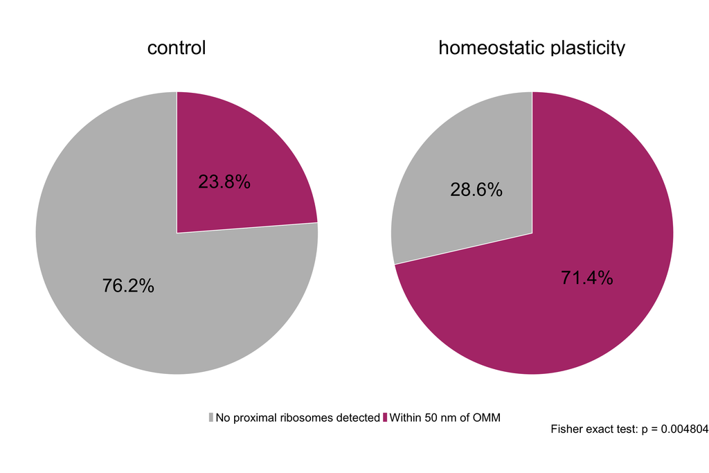

```r
set.seed(20261109)
fig5e_plot <- ggplot(summary_table, aes(x=1,y=n_Regions,fill=Category)) +
  geom_col(width=1,color="white",linewidth=1) +
  geom_text(aes(label=paste0(round(Percent,1),"%")),
            position=position_stack(vjust=0.5),size=20) +
  coord_polar(theta="y") +
  facet_wrap(~Condition, labeller=as_labeller(c(Control="control",TTX="homeostatic plasticity"))) +
  scale_fill_manual(values=c("Within 50 nm of OMM"="#B33A78",
                             "No proximal ribosomes detected"="#BDBDBD")) +
  labs(caption=paste0("Fisher exact test: p = ",format.pval(pval,digits=4))) +
  theme_void() + theme(plot.background=element_rect(fill="white",color=NA), strip.text=element_text(size=60),legend.text=element_text(size=35),
                      legend.title=element_blank(),legend.position="bottom",
                      plot.caption=element_text(size=35))
fig5e_plot
```